# pres_nonlinear_control slides

## Nonlinear Control Systems

### MEC 560: Advanced control systems

#### Vivek Yadav, PhD

## Overview

- Nonlinear systems
- Linear method for nonlinear systems?
- Lie derivatives
- Lie brackets
- Examples

### Nonlinear control system

A general nonlinear control system is given by,

$$ \dot{X} = f(X,u) $$

with measurement

$$ y = h(X,u) $$

### Affine nonlinear control system

$$ \dot{X} = f(X) + g(X) u $$

with measurement

$$ y = h(X) $$

then the system is called affine system dynamics.

Few more classifications

1. Affine vs nonaffine
2. Underactuated vs fully actuated
3. Autonomous vs nonautonomous
4. Drift vs drift free systems

1. Numerical simulations and graphical methods
2. Linearizing and studying local properties
3. Lyapunov method
4. Studying vector fields using Lie algebra

### Linearizing

Taylor series expansion about a point \( X_e \) and control \( u_e \),

$$ \dot{\delta X } = \left. \frac{\partial f}{\partial X} \right|_{X_e,u_e} \delta X + \left. \frac{\partial f}{\partial u} \right|_{X_e,u_e} \delta u $$

with measurement

$$ \delta y = \left. \frac{\partial h}{\partial X} \right|_{X_e,u_e} \delta X + \left. \frac{\partial fh}{\partial u} \right|_{X_e,u_e} \delta u $$

Once we have the linearized system, the linear system methods for controllability, observability etc can be applied to study the behavior of the system in the local neighborhood of the \( X_e \) and \( u_e \).

#### Example:

Consider the example of a simple unicycle, the kinetic equations of motion are given by,

$$ \dot{X}_1 = u_1 cos(X_3) $$

$$ \dot{X}_2 = u_1 sin(X_3) $$

$$ \dot{X}_3 = u_2 $$

### Linearize

\( \bar{X} \) and \( u_1=u_2=0 \). The linearized system is given by,

$$ \dot{e}_1 = \delta u_1 cos(\bar{X}_3) $$

$$ \dot{e}_2 = \delta u_1 sin(\bar{X}_3) $$

$$ \dot{e}_3 = \delta u_2 $$

### Linearized system

$$ \left[ \begin{array}{c} \dot{e}_1 \\ \dot{e}_2 \\ \dot{e}_3 \end{array} \right] = \left[ \begin{array}{cc} cos(\bar{X}_3) & 0 \\ sin(\bar{X}_3) & 0 \\ 0 & 1 \end{array} \right] \left[ \begin{array}{c} \delta u_1 \\ \delta u_2 \end{array} \right] $$

Linearized system is uncontrollable (as A = 0), controllability matrix is a null matrix. However, the original system is controllable.

### Lie derivatives for control systems:

Lie derivatives provide a geometric method of computing change in tensor field described by one function along the direction (flow) of another vector field.

### Lie derivatives

Lie derivative of a function \( h:R^n \rightarrow R^n \) with respect to flow along \( f:R^n \rightarrow R^n \) is given by,

$$ L_f h = \frac{dh}{dX}f $$

Compound Lie derivatives can be computed by computing Lie derivatives from in to out. Therefore,

$$ L_f^2 h = L_f (L_f h)= L_f \left( \frac{dh}{dX}f \right) = \left( \frac{d^2h}{dX^2}f + \frac{dh}{dX} \frac{df}{dX} \right) f$$

Similarly,

$$ L_g L_f h = L_g (L_f h)= L_g \left( \frac{dh}{dX}f \right) = \left( \frac{d^2h}{dX^2}f + \frac{dh}{dX} \frac{df}{dX} \right) g $$

In addition, a Lie Bracket (or adjoint) is defined between two vector fields as,

$$ adj_f g = [f,g] (X) = \frac{\partial g}{\partial X} f(X) - \frac{\partial f}{\partial X} g(X) $$

### Intuition for testing controllability,

Consider the case where system dynamics is given in the form,

$$ \dot{X} = g_1(X) u_1 + g_2(X) u_2 $$

Apply a controls in following sequence,

$$ \begin{array}{cc} u_1 = 1, u2 = 0 & t \in [0,\epsilon/4] \\ u_1 = 0, u2 = 1 & t \in [\epsilon/4,\epsilon/2] \\ u_1 = -1, u2 = 0 & t \in [\epsilon/2,3\epsilon/4] \\ u_1 = -1, u2 = 0 & t \in [3\epsilon/4,\epsilon] \end{array} $$

Where epsilon is a very small time interval.

After significant algebra, it can be shown that the control sequence described above gives a new direction as,

$$ [g_1,g_2] (X) = \frac{\partial g_2}{\partial X} g_1 (X) - \frac{\partial g_1}{\partial X} g_2(X) $$

Therefore if \( [g_1,g_2] \) gives a new direction, which is not in the span of \( g_1,g_2\), then movement in non-feasible direction can be obtained.

### Kinetic unicycle example

[figure not shown]

$$ \left[ \begin{array}{c} \dot{X}_1 \\ \dot{X}_2 \\ \dot{X}_3 \end{array} \right] = \left[ \begin{array}{cc} cos(X_3) & 0 \\ sin(X_3) & 0 \\ 0 & 1 \end{array} \right] \left[ \begin{array}{c} u_1 \\ u_2 \end{array} \right] = \underbrace{\left[ \begin{array}{c} cos(X_3) \\ sin(X_3) \\ 0 \end{array} \right]}_{g_1} u_1 + \underbrace{\left[ \begin{array}{c} 0 \\ 0 \\ 1 \end{array} \right]}_{g_2} u_2$$

The Lie bracket of \(g_1 \) and \(g_2\) is,

$$ [g_1,g_2] = - \left[ \begin{array}{ccc} 0 & 0 & -sin(X_3) \\ 0 & 0 & cos(X_3) \\ 0 & 0 & 0 \end{array} \right] \left[ \begin{array}{c} 0 \\ 0 \\ 1 \end{array} \right] + 0 = \left[ \begin{array}{c} sin(X_3) \\ - cos(X_3) \\ 0 \end{array} \right] $$

Therefore, movement in perpendicular direction can be obtained.

For drift-free systems, controllability is given by,

$$ M_g = [g_i~[g_i,g_j]~ [g_k,[g_i,g_j]] \dots ] $$

If the matrix above has full rank, then the states of the system are controllable, and can be driven to any desired value.

### Example 2: Kinematic car model

[figure not shown]

The kinematic car model is given by,

$$ sin(\theta) \dot{x} - cos(\theta) \dot{y} = 0 $$

$$ sin(\theta + \phi) \dot{x} - cos(\theta + \phi) \dot{y} - d cos(\phi) \dot{\theta} = 0 $$

These equations can be written as,

$$ \left[ \begin{array}{cccc} sin(\theta) & - cos(\theta) & 0 & 0 \end{array} \right] \dot{q} = 0 $$

$$ \left[ \begin{array}{cccc} sin(\theta + \phi) & - cos(\theta + \phi) & -d cos(\phi) & 0 \end{array} \right] \dot{q} = 0 $$

where, \( q = [x,y,\theta,\phi] \).

Say d = 1,

$$ \left[ \begin{array}{c} \dot{x} \\ \dot{y} \\ \dot{\theta} \\ \dot{ \phi} \end{array} \right] = \underbrace{\left[ \begin{array}{c} 0 \\ 0 \\ 0 \\ 1 \end{array} \right]}_{steer} u_1 + \underbrace{\left[ \begin{array}{c} cos(\theta+\phi) \\ sin(\theta+\phi) \\ sin(\phi) \\ 0 \end{array} \right]}_{drive} u_2 $$

#### Compute lie bracket of [steer,drive] (defined as wriggle analogous to twisting)

$$ [g_1,g_2] (X) = \frac{\partial g_2}{\partial X} g_1 (X) - \frac{\partial g_1}{\partial X} g_2(X) $$

$$ \left[ \begin{array}{cccc} 0 & 0 & -sin(\theta + \phi) & -sin(\theta + \phi) \\ 0 & 0 & cos(\theta + \phi) & cos(\theta + \phi) \\ 0 & 0 & 0 & cos(\phi) \\ 0 & 0 & 0 & 0\end{array} \right] \left[ \begin{array}{c} 0 \\ 0 \\ 0 \\ 1 \end{array} \right] - 0 $$$$ Wriggle = \left[ \begin{array}{c} -sin(\theta + \phi) \\ cos(\theta + \phi) \\ cos(\phi) \\ 0\end{array} \right] $$

#### Compute lie bracket of [wriggle,drive]

$$ Wriggle = \left[ \begin{array}{c} -sin(\theta + \phi) \\ cos(\theta + \phi) \\ cos(\phi) \\ 0\end{array} \right] , Drive = \left[ \begin{array}{c} cos(\theta+\phi) \\ sin(\theta+\phi) \\ sin(\phi) \\ 0 \end{array} \right]$$

[wriggle,drive] = ?

$$ \left[ \begin{array}{cccc} 0 & 0 & -sin(\theta + \phi) & -sin(\theta + \phi) \\ 0 & 0 & cos(\theta + \phi) & cos(\theta + \phi) \\ 0 & 0 & 0 & cos(\phi) \\ 0 & 0 & 0 & 0\end{array} \right] \left[ \begin{array}{c} -sin(\theta + \phi) \\ cos(\theta + \phi) \\ cos(\phi) \\ 0\end{array} \right] - \left[ \begin{array}{cccc} 0 & 0 & -cos(\theta + \phi) & -cos(\theta + \phi) \\ 0 & 0 & -sin(\theta + \phi) & -sin(\theta + \phi) \\ 0 & 0 & 0 & -sin(\phi) \\ 0 & 0 & 0 & 0\end{array} \right] \left[ \begin{array}{c} cos(\theta+\phi) \\ sin(\theta+\phi) \\ sin(\phi) \\ 0 \end{array} \right] $$

### Solving expression above gives additional direction

$$ \left[ \begin{array}{c} - sin(\theta) \\ cos(\theta ) \\ 0 \\ 0 \end{array} \right] $$

### Controllability for nonlinear system.

Consider the system,

$$\dot{X} = f(X) + g(X) u $$

Note this is a special case of drift-less system with \( u_f = 1\).

It is very difficult to quantify controllability of the system on entire state space, but local controllability about a point can be defined using adjoints as,

$$ M_{fg} = \left[ \begin{array}{ccccc} adj_f^0 g(X) & adj_f^1 g(X) & adj_f^2 g(X) & \dots & adj_f^{n-1} g(X) &\end{array} \right] $$

where,

$$ adj_f^0 g = g(X) $$$$ adj_f^1 g = [f,g] (X) = \frac{\partial g}{\partial X} f(X) - \frac{\partial f}{\partial X} g(X) $$$$ adj_f^2 g = [f,[f,g]] (X) $$

and so on.

## Example:

$$ \dot{X}_1 = X_2^2$$

$$\dot{X}_2 = u $$

Compute the controllability matrix using Lie Derivatives.

Note,

$$ adj_f g = [f,g] (X) = \frac{\partial g}{\partial X} f(X) - \frac{\partial f}{\partial X} g(X) $$

### Solution

$$ \left[ \begin{array}{c}\dot{X}_1 \\ \dot{X}_2 \end{array} \right] = \left[ \begin{array}{c} X_2^2 \\ 0 \end{array} \right] + \left[ \begin{array}{c} 0 \\ 1 \end{array} \right]u $$

$$ adj_f g = [f,g] (X) = \frac{\partial g}{\partial X} f(X) - \frac{\partial f}{\partial X} g(X) $$

$$ [f,[f,g]] = \left[ \begin{array}{cc} 0 & -2 \\ 0 & 0 \end{array} \right] \left[ \begin{array}{c} X_2 ^2 \\ 0 \end{array} \right] - \left[ \begin{array}{cc} 0 & 2X_2 \\ 0 & 0 \end{array} \right] \left[ \begin{array}{c} X_2^2 \\ 0 \end{array} \right] = 0 $$

\( [g,[f,g],[f,[f,g]]] \) is not controllable.

However, if we use,

$$ [g,[f,g]] = \left[ \begin{array}{cc} 0 & -2 \\ 0 & 0 \end{array} \right] \left[ \begin{array}{c} 0 \\ 1 \end{array} \right] - 0 = \left[ \begin{array}{c} -2 \\ 0 \end{array} \right] $$

Therefore, we have 2 distince directions, and the system is controllable. However, for \(X_1 > 0\), \(X_1\) is always increasing, therefore states are not controllable.

**NONLINEAR SYSTEMS ARE TOUGH TO WORK WITH***

### Lyapunov approach

$$ \dot{X}_1 = X_2^2$$

$$\dot{X}_2 = u $$

Define Lyapunov,

$$ L(X_1,X_2) = \frac{1}{2}X_1^TX_1 + \frac{1}{2}X_2^TX_2 $$

$$ \frac{dL}{dt} = X_1^T\dot{X}_1 + X_2^T \dot{X}_2 = X_1^T X_2^2 + X_2^T u $$

When no input is applied,

$$ \frac{dL}{dt} = X_1^T\dot{X}_1 + X_2^T \dot{X}_2 = X_1^T X_2^2 $$

Dropping vector notations,

$$ \frac{dL}{dt} = X_1 X_2^2 $$

Therefore if \( X_1 > 0\), Lyapunov function is increasing and states go to infinity. And if \(X_1<0\), Lyapunov is decreasing and states go to 0, and then become positive, and the lyapunov function goes to infinity.

```matlab
clc
close all
clear all

X1_0 = -10:.35:10;
X2_0 = -10:.35:10;

mu = 0.1;

[X1_0,X2_0] = meshgrid(X1_0,X2_0);
mu = 1;
sys_vanderPol = @(t,X)[X(2)^2;0];

time_span = 0:.1:100;


[time,states] = ode45(sys_vanderPol,time_span,[-2;1]);
[time,states1] = ode45(sys_vanderPol,time_span,[2;1]);

dX1  = X2_0.^2;
dX2  = 0*X1_0;
dX1 = dX1./sqrt(dX1.^2+dX2.^2);
dX2 = dX2./sqrt(dX1.^2+dX2.^2);
```

```matlab
figure;
plot(time,states(:,1),time,states1(:,1))
```

[output not shown]

$$ \dot{X}_1 = X_2^2$$

$$\dot{X}_2 = u $$

Define Lyapunov,

$$ L(X_1,X_2) = \frac{1}{2}X_1^TX_1 + \frac{1}{2}X_2^TX_2 $$

Dropping vector notations,

Therefore, if \(X_1 < 0\) and \( (X_2^2 + 5 X_1)>0 \) for all intermediate states, then control sends the states to zero.

```matlab
clc
close all
clear all

X1_0 = -10:.35:10;
X2_0 = -10:.35:10;

mu = 0.1;

[X1_0,X2_0] = meshgrid(X1_0,X2_0);
mu = 1;
sys_vanderPol = @(t,X)[X(2)^2;-10*X(1)-10*X(2)];

time_span = 0:.1:100;

[time,states] = ode45(sys_vanderPol,time_span,  [1;-1]);
[time1,states1] = ode45(sys_vanderPol,time_span,[1;-1]);

dX1  = X2_0.^2;
dX2  = -10*X1_0-10*X2_0;
dX1 = dX1./sqrt(dX1.^2+dX2.^2);
dX2 = dX2./sqrt(dX1.^2+dX2.^2);
```

[output not shown]

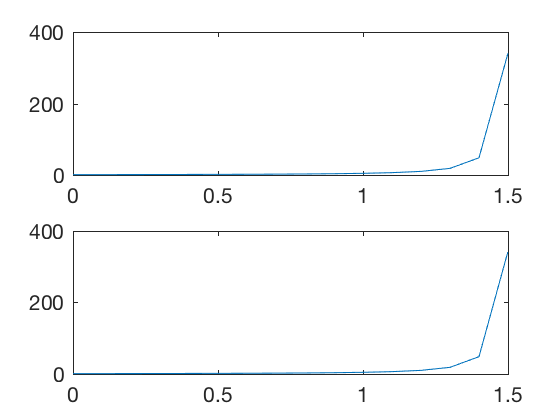

```matlab
figure;
subplot(2,1,1)
plot(time,states(:,1))
subplot(2,1,2)
plot(time1,states1(:,1))
```

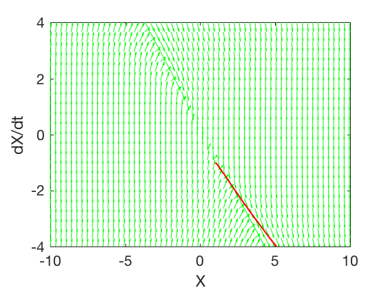

```matlab
figure;
quiver(X1_0,X2_0,dX1,dX2,1,'g')
hold on
plot(states(:,1),states(:,2),'b','linewidth',1)
plot(states1(:,1),states1(:,2),'r','linewidth',1)
axis([-10 10 -4 4])
xlabel('X');
ylabel('dX/dt');
```

### Nonlinear control:

1. Very difficult to determing controllability of the system.
2. Lyapunov methods are useful to check stability, however, designing PID-type control that ensures Lyapunov is decreasing throughout is not possible.